# knn Analysis

Kay, Belen, Amanda

4/14/2021

# Data set 1: Reviews of coffee shops

The first data set contains information from Yelp ratings for coffee shops in Austin, Texas. Each Yelp rating is logged with the name of the coffee shop, the content of the review, the numeric rating, the relative rating, whether the rating is considered high or low, the overall sentiment, the sentiment about the shop’s vibe, the sentiment about its tea offerings, the sentiment about the service they offer, etc. The question we are hoping to answer is as follows: after cleaning data to remove the data points creating noise, can we create a KNN model that uses some of these rating factors to predict whether or not the coffee shop was high rated?

## Find out which columns have many missing values so that they can be discarded

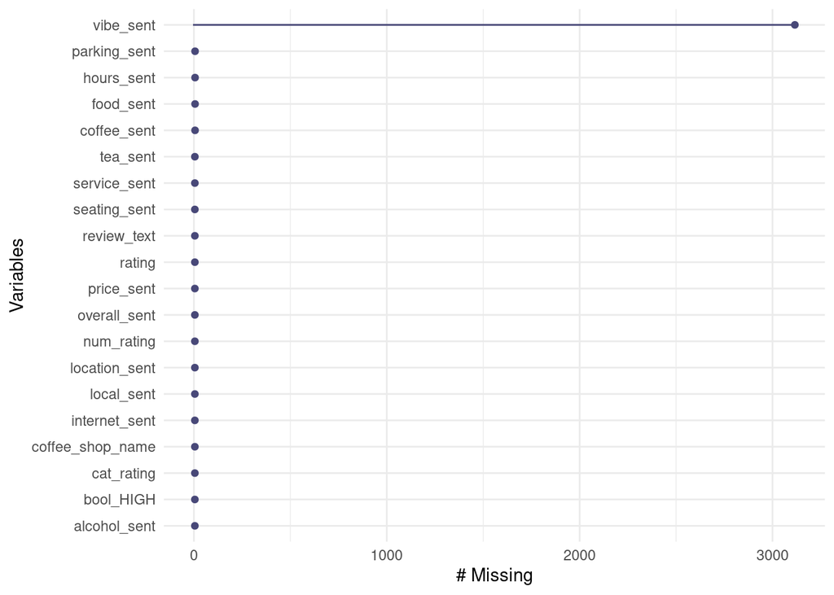

We removed the columns with many missing values and columns that affect accuracy. After that, we found that the base level for identifying if a patient would survive or not was 80.0%. In other words, there is an 80% chance that a coffee shop is high-rated.

## Plot k vs. accuracy to see how many neighbors to use

Based on the plot that was created (below), 11 is the best number of neighbors for a higher accuracy level.

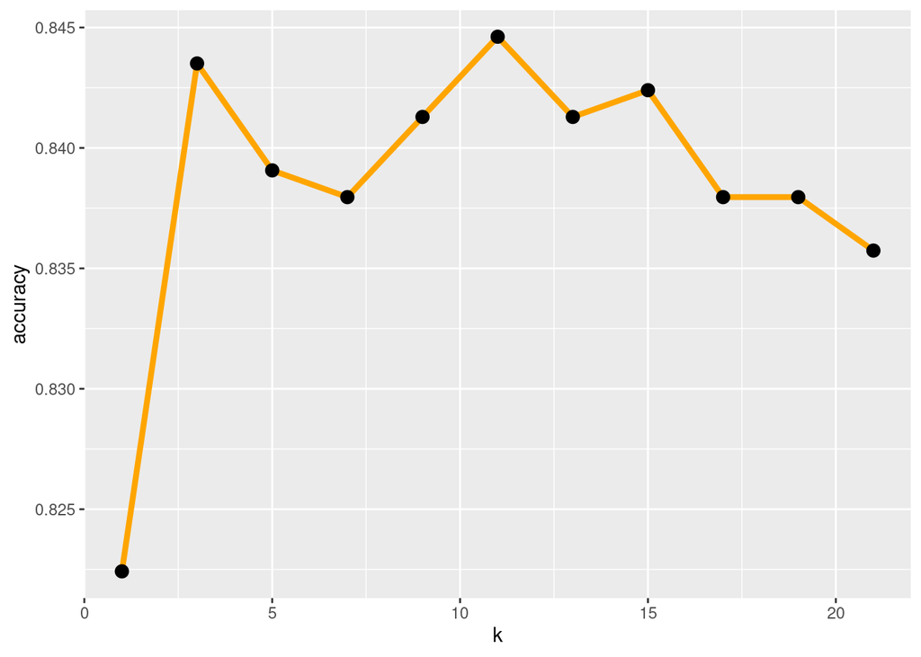

## Run KNN analysis with 11 nearest neighbors and analyze the accuracy of the model

## Evaluate model

### Confusion matrix

This confusion matrix tells us that the accuracy is 84.8%, kappa is 28.5%, sensitivity is 97.3%, specificity is 24.0%, and F1 score is 91.4% (printed separately below). These are pretty good statistics, as the accuracy has gone up from our base rate of 80%, though the kappa is pretty low. Kappa measures the degree of agreement among raters, so this is something to keep in mind when analyzing the model.

```
## Confusion Matrix and Statistics
##
##           Actual
## Prediction   0   1
##          0  37  20
##          1 117 727
##
##                Accuracy : 0.8479
##                  95% CI : (0.8228, 0.8708)
##     No Information Rate : 0.8291
##     P-Value [Acc > NIR] : 0.07051
##
##                   Kappa : 0.2847
##
##  Mcnemar's Test P-Value : 2.367e-16
##
##             Sensitivity : 0.9732
##             Specificity : 0.2403
##          Pos Pred Value : 0.8614
##          Neg Pred Value : 0.6491
##              Prevalence : 0.8291
##          Detection Rate : 0.8069
##    Detection Prevalence : 0.9367
##       Balanced Accuracy : 0.6067
##
##        'Positive' Class : 1
##
```

```
##        F1
## 0.9138906
```

### Log Loss

```
## [1] 0.5487878
```

### AUC

The area under the receiver operating curve (ROC) below tells us how much the model can distinguish between classes, aka whether or not a coffee shop is high-rated. The greater our area under the curve, the better our model is at distinguishing between well-rated and poorly-rated coffee shops in Austin. We see that our AUC prints as 0.78, which is pretty good! Note that we also plot the y = x line to visualize the difference between our model (the colorful curve) and what it would be like to just randomly guess.

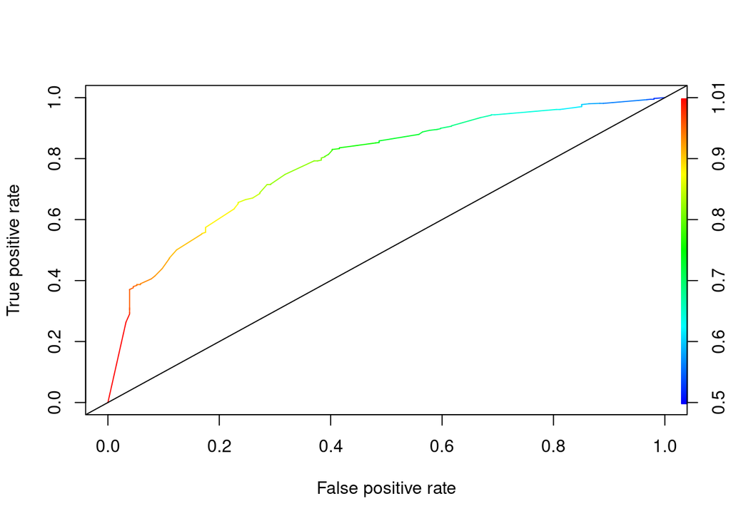

```
## [1] 0.7840714
```

## Adjust threshold

```
## Confusion Matrix and Statistics
##
##           Actual
## Prediction   0   1
##          0  50  35
##          1 104 712
##
##                Accuracy : 0.8457
##                  95% CI : (0.8205, 0.8687)
##     No Information Rate : 0.8291
##     P-Value [Acc > NIR] : 0.09853
##
##                   Kappa : 0.3379
##
##  Mcnemar's Test P-Value : 8.037e-09
##
##             Sensitivity : 0.9531
##             Specificity : 0.3247
##          Pos Pred Value : 0.8725
##          Neg Pred Value : 0.5882
##               Precision : 0.8725
##                  Recall : 0.9531
##                      F1 : 0.9111
##              Prevalence : 0.8291
##          Detection Rate : 0.7902
##    Detection Prevalence : 0.9057
##       Balanced Accuracy : 0.6389
##
##        'Positive' Class : 1
##
```

# Data set 2: Outcomes of cancer patients

This second data set contains the overall outcomes of cancer patients, along with many other data points about the patient’s health. The question we are hoping to answer is as follows: after cleaning data and removing any data points that create noise, can we create a KNN model that uses some health factors to predict whether or not the patient had a positive outcome at a rate better than the baseline?

## Find out which columns have many missing values so that they can be discarded

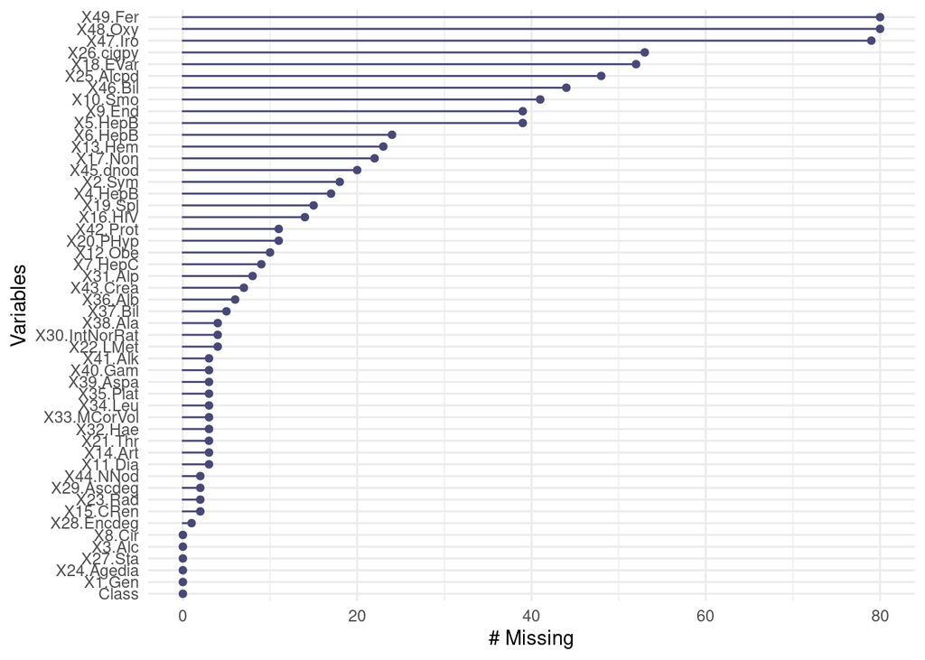

We removed the columns with many missing values and columns that affect accuracy. After that, we found that the base level for identifying if a patient would survive or not was 60.4%.

## Plot k vs. accuracy to see how many neighbors to use

Based on the plot that was created, 3 was the best number of neighbors for a higher accuracy level.

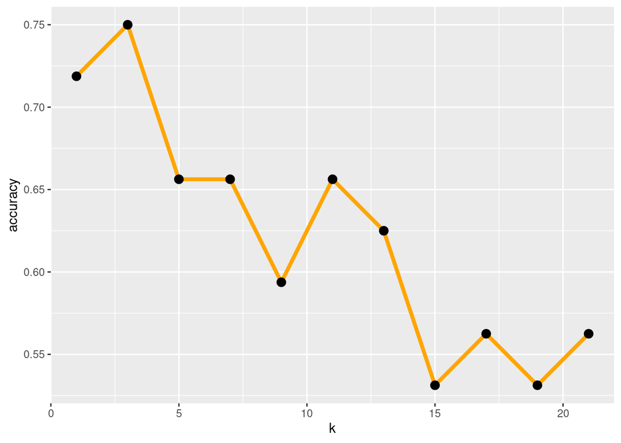

## Run KNN analysis with 3 nearest neighbors and analyze the accuracy of the model

## Evaluate model

### Confusion matrix

Originally, the baseline accuracy was around 60%; accuracy is now up to 71.8%. The sensitivity is 75%, while the specificity is 67%. This means that the false positive rate is 33%, which is a bit high but certainly not terrible. The F1 value is 76.9%. All of these statistics are fairly good, especially when you compare the baseline to the prediction model.

The kappa value is 0.410, which is relatively weak for a kappa value.

```
## Confusion Matrix and Statistics
##
##           Actual
## Prediction  0  1
##          0  8  5
##          1  4 15
##
##                Accuracy : 0.7188
##                  95% CI : (0.5325, 0.8625)
##     No Information Rate : 0.625
##     P-Value [Acc > NIR] : 0.1814
##
##                   Kappa : 0.4098
##
##  Mcnemar's Test P-Value : 1.0000
##
##             Sensitivity : 0.7500
##             Specificity : 0.6667
##          Pos Pred Value : 0.7895
##          Neg Pred Value : 0.6154
##              Prevalence : 0.6250
##          Detection Rate : 0.4688
##    Detection Prevalence : 0.5938
##       Balanced Accuracy : 0.7083
##
##        'Positive' Class : 1
##
```

### Log Loss

```
## [1] 5.795204
```

### AUC

The area under our ROC for this model is 0.458, which is not great. The shape of the curve also also suggests that the model is not much better at predicting whether a cancer patient will survive than random guessing.

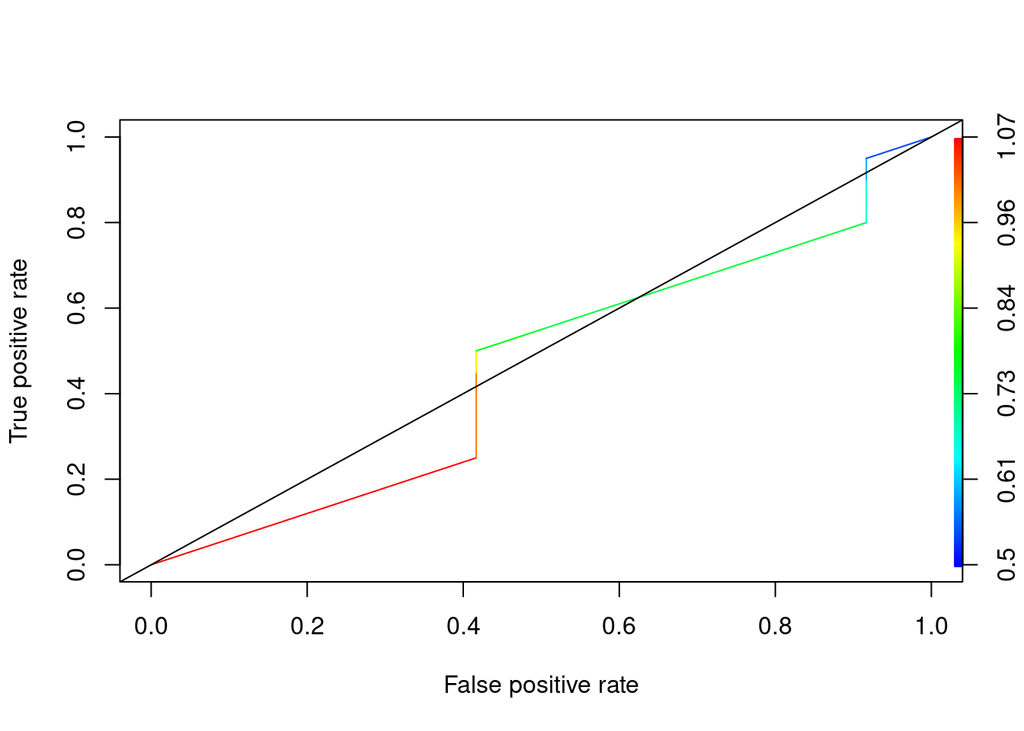

```
## [1] 0.4583333
```

## Adjust threshold

```
## Confusion Matrix and Statistics
##
##           Actual
## Prediction  0  1
##          0  9 11
##          1  3  9
##
##                Accuracy : 0.5625
##                  95% CI : (0.3766, 0.7364)
##     No Information Rate : 0.625
##     P-Value [Acc > NIR] : 0.81998
##
##                   Kappa : 0.1765
##
##  Mcnemar's Test P-Value : 0.06137
##
##             Sensitivity : 0.4500
##             Specificity : 0.7500
##          Pos Pred Value : 0.7500
##          Neg Pred Value : 0.4500
##               Precision : 0.7500
##                  Recall : 0.4500
##                      F1 : 0.5625
##              Prevalence : 0.6250
##          Detection Rate : 0.2812
##    Detection Prevalence : 0.3750
##       Balanced Accuracy : 0.6000
##
##        'Positive' Class : 1
##
```

# Concluding Analysis

This lab was very informative for evaluating our ML models in R. We had a more fruitful analysis with our first data set because we had far more data after cleaning. It was hard to analyze our second model, since small adjustments could make massive changes and not be very representative. For example, we may have found that adjusting the threshold to something above 0.5 was actually helpful if we had a larger data set.

For future extensions from this lab, we would have liked to create a function that adjusted the threshold for our model for all increments of 0.05 and made the decisions as to which threshold was “best”. It would be very dependent on the goal of the model, as well as the data itself, as to what metric(s) to prioritize. Since we were just practicing evaluating models with 2 random data sets, we weren’t able to make a decision as to what was most important with our model. That being said, if Yelp wanted to use the model trained on data set #1 (ratings for all ratings for Austin coffee shops) to sort coffee shops by top-rated, for example, they could decide to prioritize accuracy.